# Music & Mental Health

#### Proporcja liczby osób słuchających z daną częstotliwością słuchania ulubionego gatunku do wszystkich osób słuchających tego gatunku z tą częstotliwością słuchania

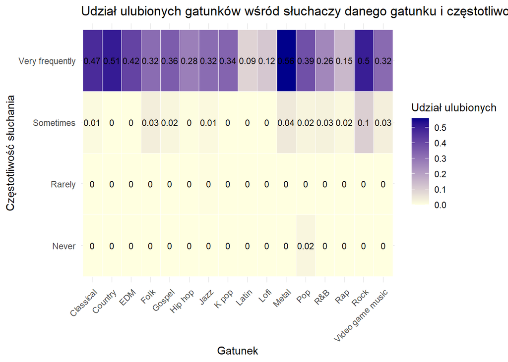

Silna preferencja ulubionego gatunku wiąże się z jego regularnym słuchaniem (Very frequently). Oczywiście dla pozostałych kategorii częstotliwości (Sometimes, Rarely, Never) udział ulubionych gatunków jest znikomy lub zerowy. Wizualizacja pokazuje, że osoby słuchające bardzo często gatunków takich jak metal, country czy rock, znacznie częściej wskazują je jako ulubione – w przeciwieństwie do słuchaczy lofi, latin czy rapu. Może to wynikać z faktu, że metal, country i rock są silnie związane z konkretnymi subkulturami i tożsamością słuchaczy, częściej spotykaną wśród starszych odbiorców z bardziej ugruntowanymi gustami muzycznymi. Natomiast młodsi słuchacze, którzy dominują wśród fanów rapu, lofi czy latino, często słuchają wielu różnych gatunków, niekoniecznie mając jeden ulubiony – co może odzwierciedlać większą otwartość i zmienność preferencji. Dodatkowo, gatunki takie jak lofi czy latin mogą być słuchane bardziej użytkowo (np. do nauki, relaksu, zabawy), a nie emocjonalnie, co także może ograniczać ich postrzeganie jako „ulubionych”.

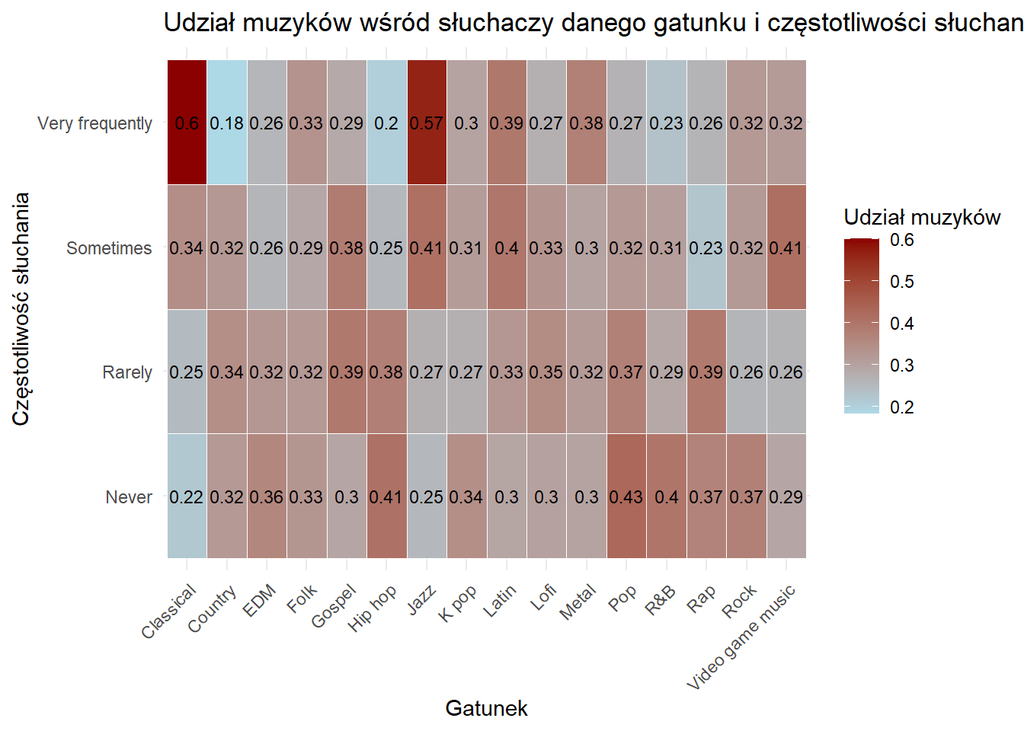

Wykres pokazuje, że najwyższy udział muzyków wśród słuchaczy „Very frequently” dotyczy muzyki klasycznej (60%) i jazzu (57%) – oba te gatunki są silnie powiązane z formalnym wykształceniem muzycznym, wymagają dużych umiejętności technicznych i są obecne w edukacji muzycznej, co przyciąga osoby aktywnie grające. Odwrotnie sytuacja wygląda dla country, hip-hopu i R&B, gdzie udział muzyków jest relatywnie niski nawet wśród częstych słuchaczy – sugeruje to, że te gatunki są bardziej konsumenckie, tzn. słuchane głównie przez osoby nieuprawiające muzyki. Ciekawym zjawiskiem jest to, że osoby, które w ogóle nie słuchają popu, R&B, rapu, hip-hopu czy rocka, częściej są muzykami – może to wynikać z bardziej klasycznego lub niszowego gustu muzycznego muzyków, którzy unikają komercyjnych gatunków na rzecz tych bardziej technicznych, instrumentalnych lub poważnych.

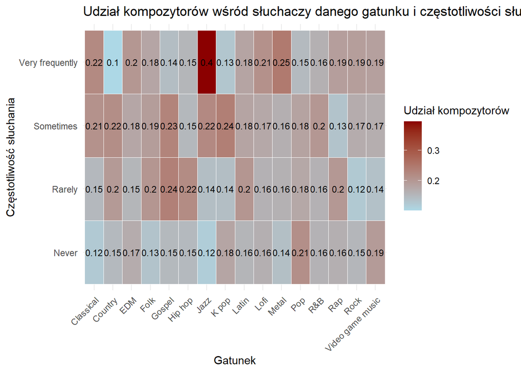

Wśród bardzo częstych słuchaczy jazzu, klasyki i metalu jest najwyższy odsetek kompozytorów – odpowiednio 40%, 22% i 25% – co może wynikać z ich muzycznej złożoności. Z kolei country, hip-hop, rap, R&B czy K-pop przyciągają mniej kompozytorów, nawet wśród często słuchających. Może to wynikać z faktu, że często opierają się na powtarzalnych schematach lub prostszych strukturach co przyciąga mniej kompozytorów. Jednak może to być jedynie charakterystyczna zależność dla tego zbioru danych.

#### Udział słuchaczy muzyki w trakcie pracy/nauki względem gatunku i częstotliwości słuchania

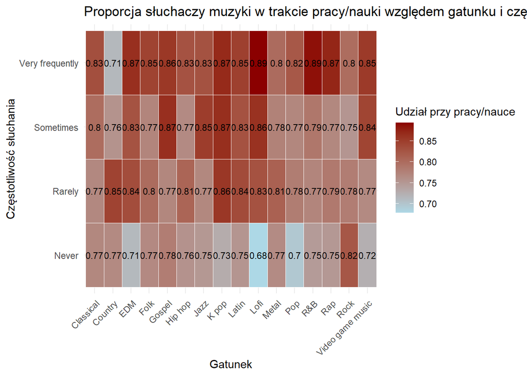

Większość często słuchanych gatunków muzycznych jest również wykorzystywana podczas pracy lub nauki. Nieco niższy udział (0.82 i mniej) obserwujemy w przypadku takich gatunków jak country, pop, metal czy rock – są to zazwyczaj utwory bardziej dynamiczne i angażujące, co może rozpraszać, dlatego rzadziej towarzyszą nauce czy pracy. Na tle innych wyraźnie wyróżnia się lofi, który osiąga prawie 90% udziału w słuchaniu podczas pracy/nauki. Co ciekawe, wśród osób, które go nie słuchają na co dzień, współczynnik ten jest najniższy w całym zestawieniu (0.68). Może to wynikać z faktu, że lofi to muzyka relaksująca, mało angażująca i najczęściej pozbawiona słów – jakby stworzona do towarzyszenia w skupieniu i pracy umysłowej.

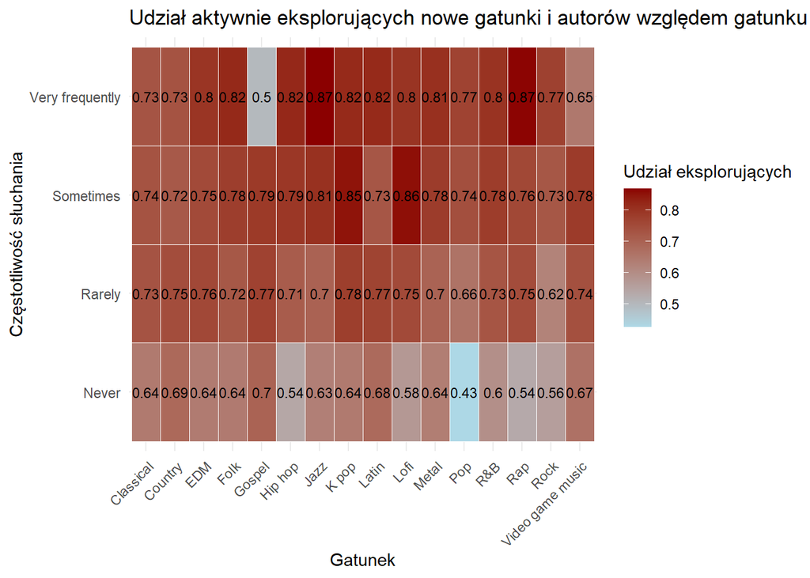

Osoby często słuchające rapu i jazzu wykazują wysoką skłonność do eksplorowania nowych wykonawców i gatunków, co może wynikać z dynamicznego charakteru tych stylów – rap nieustannie się zmienia i przyciąga nowymi trendami, a jazz opiera się na improwizacji i fuzjach, co naturalnie sprzyja otwartości na nowe brzmienia. W przeciwieństwie do tego, osoby bardzo często słuchające gospelu mają niski współczynnik eksploracji (0,5), co może być związane z silnym emocjonalnym i duchowym przywiązaniem do konkretnych utworów i wykonawców – w tym przypadku muzyka pełni bardziej stałą, rytualną funkcję niż rozrywkową. Ciekawa jest też sytuacja popu – wśród osób, które deklarują, że go nie słuchają, eksploracja muzyczna jest bardzo niska. Może to wynikać z faktu, że pop jest wszędzie obecny i trudno go zupełnie uniknąć; jeśli ktoś to robi, najczęściej świadomie ogranicza się do jednego, alternatywnego stylu, rezygnując z poszukiwania nowych brzmień.

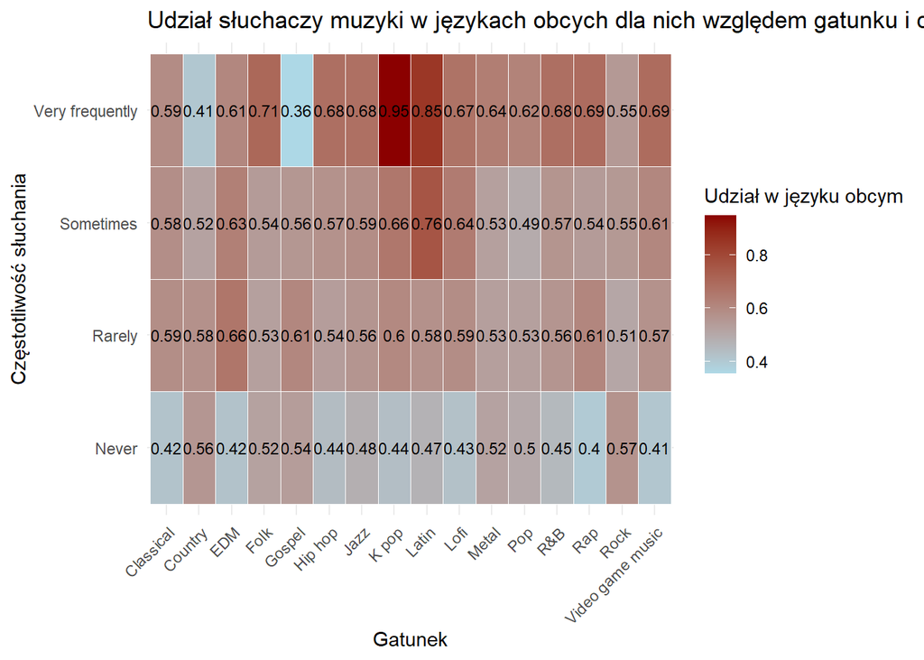

W danych wyraźnie widoczne są istotne różnice między gatunkami pod względem udziału muzyki w językach obcych. K-pop (95%) i Latin (85%) to gatunki, które są niemal zawsze słuchane w językach innych niż ojczysty – co wynika z ich międzynarodowego charakteru i popularności poza krajem pochodzenia słuchaczy. Z kolei Gospel (36%) i Country (41%) mają najniższy udział muzyki obcojęzycznej, nawet wśród osób słuchających ich bardzo często. Są to style silnie związane z lokalną tradycją i tożsamością kulturową, przez co rzadziej występują w wersjach językowo zróżnicowanych.

## Imputacja i usuwanie brakujących danych

#### Liczba braków danych

```r
sum(is.na(df))
```

```
## [1] 121
```

#### Liczba braków danych dla każdej kolumny

```r
colSums(is.na(df))
```

```
##                          Age    Primary streaming service
##                            1                            1
##                Hours per day                While working
##                            0                            3
##              Instrumentalist                     Composer
##                            4                            1
##                    Fav genre                  Exploratory
##                            0                            0
##            Foreign languages                          BPM
##                            4                          107
##        Frequency [Classical]          Frequency [Country]
##                            0                            0
##              Frequency [EDM]             Frequency [Folk]
##                            0                            0
##           Frequency [Gospel]          Frequency [Hip hop]
##                            0                            0
##             Frequency [Jazz]            Frequency [K pop]
##                            0                            0
##            Frequency [Latin]             Frequency [Lofi]
##                            0                            0
##            Frequency [Metal]              Frequency [Pop]
##                            0                            0
##              Frequency [R&B]              Frequency [Rap]
##                            0                            0
##             Frequency [Rock] Frequency [Video game music]
##                            0                            0
##                   Depression
##                            0
```

Braki danych występują w kilku kolumnach, jednak w większości przypadków jest ich bardzo niewiele. Najwięcej braków znajduje się w kolumnie BPM, gdzie odnotowano 107 brakujących wartości.

#### Liczba braków danych dla wierszy

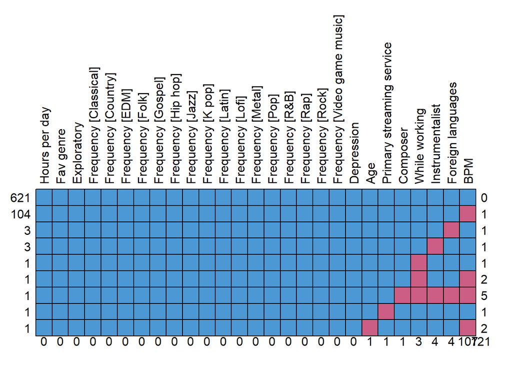

```r
res <- md.pattern(df, plot = TRUE, rotate.names = TRUE)
```

Mamy 104 obserwacje z pojedyńczym brakiem danych w kolumnie BPM. Pozostałe braki danych są już jednostkowe. Mamy jedną obserwację gdzie brakuje 5 wartości, ponieważ jest tylko jedna to taką obserwację poprostu usuwamy. Braki danych z kolumny BPM uzupełnimy średnimi grupowymi dla konkretnych gatunków muzycznych, ponieważ w ten sposób dane będą bardziej rzeczywiste niż gdybyśmy uzupełnili je średnią dla całej kolumny.

#### Odstające wartości w kolumnie BPM

```r
data$BPM[data$BPM >= 600 | data$BPM <= 20] <- NA
```

Nierealne wartości BPM (8 obserwacji) zastąpiliśmy brakami danych, ponieważ lepsze to niż tracenie informacji.

#### Uzupełnianie braków danych w kolumnie BPM

```r
means <- aggregate(BPM ~ `Fav genre`, data = data, FUN = function(x) round(mean(x[x > 0], na.rm = TRUE), 0))
```

```r
set.seed(123)

idx <- which(is.na(data$BPM))
values <- numeric(length(idx))

m <- rnorm(length(idx), mean = 1, sd = 0.05)

for (j in 1:115) {
  genre <- data$`Fav genre`[idx[j]]
  base <- means[means$`Fav genre` == genre, 'BPM']
  values[j] <- base * m[j]
}

data$BPM[idx] <- round(values, 0)
```

Braki danych w zmiennej BPM zostały uzupełnione średnimi grupowymi z dodaniem losowego szumu, a następnie zaokrąglone do wartości całkowitych, ponieważ tylko takie wartości mają sens logiczny w kontekście BPM.

#### Wartości którymi wypełniono braki danych w kolumnie BPM

```r
data[idx, c("Fav genre", "BPM")] %>%
  mutate(Index = idx) %>%
  select(Index, `Fav genre`, BPM) %>%
  arrange(`Fav genre`)
```

```
## # A tibble: 115 × 3
##    Index `Fav genre`   BPM
##    <int> <fct>       <dbl>
##  1    56 Classical     118
##  2   243 Classical     120
##  3   260 Classical     119
##  4   267 Classical     115
##  5   369 Classical     123
##  6   384 Classical     106
##  7   385 Classical     118
##  8   391 Classical     116
##  9   400 Classical     116
## 10   415 Classical     113
## # ℹ 105 more rows
```

#### Sprawdzenie jakie braki danych nam zostały po usunięciu tych z kolumny BPM

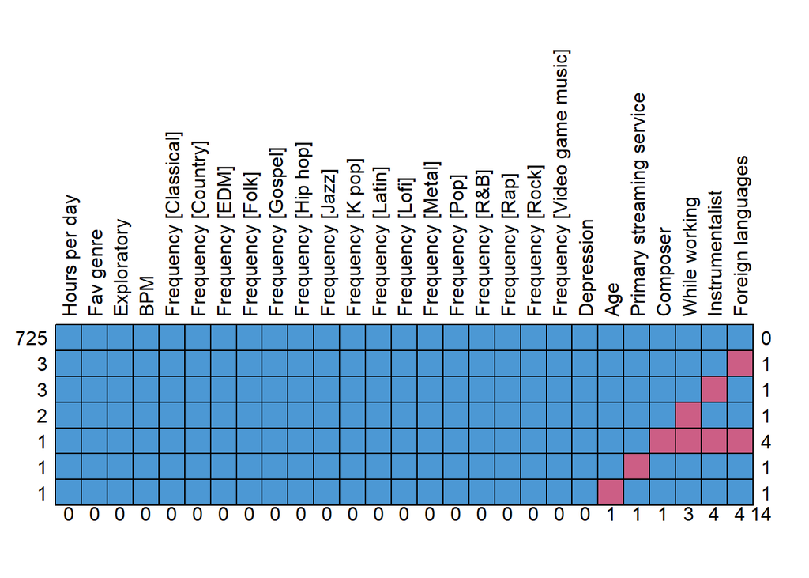

```r
res <- md.pattern(data, plot = TRUE, rotate.names = TRUE)
```

#### Usunięcie wiersza z czterema brakami danych

```r
data <- data[rowSums(is.na(data)) != 4, ]
```

Po usunięciu pojedyńczego wiersza z 4 brakami danych pozostają już nam jedynie obserwacje z pojedyńczymi brakami. Uzupełnimy je proprzez imputację z wykorzystaniem pakietu `mice`.

```r
set.seed(2025)

colnames(data) <- make.names(colnames(data))

imp <- mice(data,
            m = 1,
            seed = 2025,
            printFlag = F)


data <- complete(imp,1)
```

#### Rezultat usuwania i uzupełniania braków danych

```
##  /\     /\
## {  `---'  }
## {  O   O  }
## ==>  V <==  No need for mice. This data set is completely observed.
##  \  \|/  /
##   `-----'
```

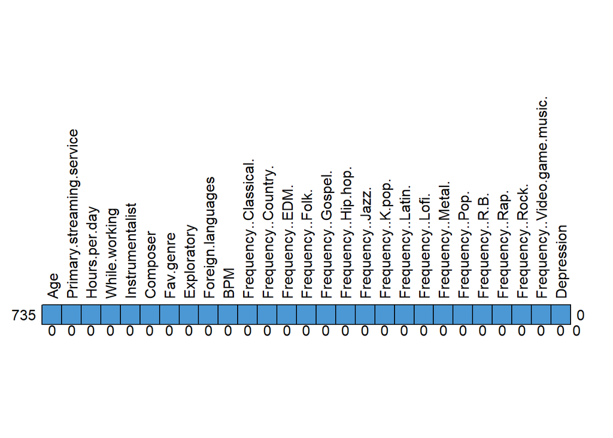

```r
res <- md.pattern(data, plot = TRUE, rotate.names = TRUE)
```

Jak widać pozostają nam 735 obserwacje bez braków danych.

#### Zapisywanie zbioru danych po uzupełnieniu oraz usunięciu wszystkich braków danych

```r
#saveRDS(data, "data_no_missing_values.rds")
```

## Budowa modeli

### Wstępne modelowanie

#### Podział danych na zbiór treningowy i testowy

```r
set.seed(123)

split <- initial_split(df, prop = 0.8, strata = "Depression")
train <- training(split)
test <- testing(split)
```

Dzielimy dane na zbiór uczący oraz testowy z zachowaniem proporcji klas w kolumnie `Depression`.

#### Inicjalizacja modeli do uczenia

```r
models <- list(
            nb = naive_Bayes(mode = "classification",
                             engine = "klaR"),

            svm = svm_rbf(mode = "classification",
                         engine = "kernlab"),

            dt = decision_tree(mode = "classification",
                               engine = "rpart"),

            mlp = mlp(mode = "classification",
                      engine = "nnet"),

            knn = nearest_neighbor(mode = "classification",
                                   engine = "kknn"),

            rf = rand_forest(mode = "classification",
                             engine = "ranger"),

            xgb = boost_tree(mode = "classification",
                             engine = "xgboost"),

            lda = discrim_linear(mode = "classification",
                                 engine = "MASS")
)
```

Inicjalizujemy listę modeli kolejno: Naive Bayes, SVM, Decision Tree, MLP, KNN, Random Forest, XGBoost oraz LDA. Celem tego etapu jest wstępna ocena skuteczności różnych rodzin modeli na naszych danych. Na podstawie uzyskanych wyników wybierzemy cztery najlepiej rokujące algorytmy, które następnie zostaną poddane dalszej analizie i dostrajaniu hiperparametrów.

#### Utworzenie przepisów przetwarzania danych

```r
recipes <- list(
            rec_norm = recipe(Depression ~ ., data = train) %>%
                        step_normalize(all_numeric_predictors())  %>%
                        step_dummy(all_nominal_predictors()),

            rec_pca_60 = recipe(Depression ~ ., data = train) %>%
                        step_normalize(all_numeric_predictors()) %>%
                        step_dummy(all_nominal_predictors()) %>%
                        step_pca(all_predictors(), threshold = 0.6),

            rec_pca_80 = recipe(Depression ~ ., data = train) %>%
                        step_normalize(all_numeric_predictors()) %>%
                        step_dummy(all_nominal_predictors()) %>%
                        step_pca(all_predictors(), threshold = 0.8)
)
```

Będziemy testować modele na różnych poziomach PCA. Przetestowanie modeli z różnymi wariantami przygotowania danych pozwoli na ocenę, która metoda wstępnego przetwarzania jest najkorzystniejsza dla danego algorytmu.

#### Utworzenie przepływów modelowania

```r
wflows <- workflow_set(
            preproc = recipes,
            models = models,
            cross = TRUE
)
```

Tworzymy obiekt workflow_set z flagą cross=TRUE, czyli każdy model zostanie przetestowany na każdym przepisie.

#### Generowanie foldów walidacyjnych

```r
folds <- vfold_cv(train, v = 10)
```

Tworzymy 10-krotną walidację krzyżową na zbiorze treningowym.

#### Trenowanie modeli

```r
registerDoParallel(cores = parallel::detectCores() - 1)
keep_pred <- control_resamples(save_pred = TRUE, save_workflow = TRUE)

initial_wflows <- wflows %>%
                    workflow_map(
                      "fit_resamples",
                      resamples = folds,
                      control = keep_pred,
                      verbose = FALSE
)
```

Na tym etapie przeprowadzamy trenowanie wszystkich wcześniej przygotowanych modeli z wykorzystaniem walidacji krzyżowej. Dzięki temu możemy porównać ich skuteczność oraz wyłonić te algorytmy, które najlepiej radzą sobie z naszym problemem.

#### Wyniki dla procesu modelowania

```r
initial_wflows %>%
  collect_metrics() %>%
  group_by(.metric) %>%
  arrange(.metric, desc(mean))
```

```
## # A tibble: 72 × 9
## # Groups:   .metric [3]
##    wflow_id       .config   preproc model .metric .estimator  mean     n std_err
##    <chr>          <chr>     <chr>   <chr> <chr>   <chr>      <dbl> <int>   <dbl>
##  1 rec_pca_60_svm Preproce… recipe  svm_… accura… multiclass 0.447    10  0.0213
##  2 rec_pca_80_rf  Preproce… recipe  rand… accura… multiclass 0.438    10  0.0233
##  3 rec_norm_rf    Preproce… recipe  rand… accura… multiclass 0.437    10  0.0230
##  4 rec_pca_80_svm Preproce… recipe  svm_… accura… multiclass 0.433    10  0.0224
##  5 rec_norm_svm   Preproce… recipe  svm_… accura… multiclass 0.428    10  0.0192
##  6 rec_pca_60_xgb Preproce… recipe  boos… accura… multiclass 0.422    10  0.0257
##  7 rec_pca_80_lda Preproce… recipe  disc… accura… multiclass 0.421    10  0.0220
##  8 rec_pca_60_rf  Preproce… recipe  rand… accura… multiclass 0.415    10  0.0199
##  9 rec_pca_60_lda Preproce… recipe  disc… accura… multiclass 0.406    10  0.0200
## 10 rec_pca_60_nb  Preproce… recipe  naiv… accura… multiclass 0.401    10  0.0262
## # ℹ 62 more rows
```

Ze wstępnych wyników do dalszej części weźmiemy modele LDA, Random Forest, SVM oraz XGBoost.

#### Zapisanie wyników wstępnego modelowania

```r
#saveRDS(wflows, "mxmh_initial_models.rds")
```

### Dostrajanie hiperparametrów wybranych modeli

#### Podział danych na zbiór treningowy i testowy

```r
set.seed(123)

df_split <- initial_split(df, prop = 0.75, strata = "Depression")
df_train <- training(df_split)
df_test <- testing(df_split)
```

Nie mamy zbyt wiele danych do testowania, dlatego do tej części uczenia użyjemy 75% danych.

#### Inicjalizacja modeli do treningu i strojenia hiperparametrów najlepszych algorytmów

```r
models <- list(
            lda = discrim_linear(
              regularization_method = "diagonal",
              penalty = tune(),
              mode = "classification") %>%
              set_engine("mda"),

            rf = rand_forest(
              trees = tune(),
              min_n = tune(),
              mtry = tune(),
              mode = "classification") %>%
              set_engine("ranger"),

            xgb = boost_tree(
              trees = tune(),
              min_n = tune(),
              mtry = tune(),
              learn_rate = tune(),
              mode = "classification") %>%
              set_engine("xgboost"),

            svm = svm_rbf(
              cost = tune(),
              rbf_sigma = tune(),
              mode = "classification") %>%
              set_engine("kernlab")
)
```

Inicjalizujemy cztery modele, które osiągnęły najlepsze wyniki w etapie wstępnego trenowania. Modele te zostaną teraz poddane strojeniu hiperparametrów w celu dalszej poprawy ich skuteczności.

#### Utworzenie przepisów przetwarzania danych

```r
recipes <- list(
            rec_lda = recipe(Depression ~ ., data = df_train) %>%
                        step_normalize(all_numeric_predictors()) %>%
                        step_dummy(all_nominal_predictors()) %>%
                        step_pca(starts_with("Frequency"), num_comp = 12) %>%
                        step_pca(all_predictors(), threshold = 0.85, prefix = "pca_"),

            rec_rf = recipe(Depression ~ ., data = df_train) %>%
                        step_normalize(all_numeric_predictors())  %>%
                        step_dummy(all_nominal_predictors()) %>%
                        step_pca(starts_with("Frequency"), num_comp = 12) %>%
                        step_pca(all_predictors(), threshold = 0.85, prefix = "pca_") %>%
                        step_nzv(all_predictors()),

            rec_xgb = recipe(Depression ~ ., data = df_train) %>%
                        step_normalize(all_numeric_predictors()) %>%
                        step_dummy(all_nominal_predictors()) %>%
                        step_pca(starts_with("Frequency"), num_comp = 12) %>%
                        step_pca(all_predictors(), threshold = 0.85, prefix = "pca_")%>%
                        step_nzv(all_predictors()),

            rec_svm = recipe(Depression ~ ., data = df_train) %>%
                        step_normalize(all_numeric_predictors()) %>%
                        step_dummy(all_nominal_predictors()) %>%
                        step_pca(starts_with("Frequency"), num_comp = 12) %>%
                        step_pca(all_predictors(), threshold = 0.8, prefix = "pca_")
)
```

Dobór przepisów został dokonany ze względu na to jaka jest struktura naszego zbioru danych, tj. mamy wiele kolumn typu factor oraz powiązanych ze sobą ze względu na dziedzinę jak chociażby częstotliwość słuchania różnych gatunków. Ponadto odpowiedzi są subiektywne dlatego nie niosą czystej informacji.

#### Utworzenie przepływów modelowania

```r
class_models <- workflow_set(
                  preproc = recipes,
                  models = models,
                  cross = FALSE
)
```

Tym razem uczenie będzie przebiegało w formie jeden model do jednego przepisu.

#### Generowanie foldów walidacyjnych

```r
cv_folds <- vfold_cv(df_train, v = 5, strata = "Depression")
```

Tym razem wykrozystamy 5-krotną walidację krzyżową.

#### Trenowanie modeli z walidacją krzyżową i tuningiem siatki hiperparametrów

```r
registerDoParallel(cores = parallel::detectCores() - 1)
controlGrid <- control_grid(save_pred = TRUE, save_workflow = TRUE, verbose = TRUE)

class_models <- workflow_map(
                  class_models,
                  "tune_grid",
                  resamples = cv_folds,
                  grid = 50,
                  control = controlGrid,
                  metrics = metric_set(mn_log_loss, kap),
                  verbose = TRUE,
)
```

Model będzie optymalizowany pod kątem metryki mn_log_loss, która jest dobrze dopasowana do problemów klasyfikacji wieloklasowej, ponieważ uwzględnia pewność predykcji. Do strojenia używamy siatki z 50 kombinacjami, co zapewnia wystarczającą różnorodność konfiguracji hiperparametrów, pozwalając na znalezienie optymalnych ustawień.

#### Zapisywanie wyników dostrajania hiperparametrów

```r
#saveRDS(class_models, "mxmh_models_kap3.rds")
```

#### Ocena modeli

```r
metrics <- collect_metrics(class_models)

metrics %>%
  arrange(.metric, desc(mean))
```

```
## # A tibble: 400 × 9
##    wflow_id    .config      preproc model .metric .estimator  mean     n std_err
##    <chr>       <chr>        <chr>   <chr> <chr>   <chr>      <dbl> <int>   <dbl>
##  1 rec_svm_svm Preprocesso… recipe  svm_… kap     multiclass 0.162     5  0.0384
##  2 rec_rf_rf   Preprocesso… recipe  rand… kap     multiclass 0.157     5  0.0384
##  3 rec_rf_rf   Preprocesso… recipe  rand… kap     multiclass 0.149     5  0.0383
##  4 rec_rf_rf   Preprocesso… recipe  rand… kap     multiclass 0.144     5  0.0434
##  5 rec_rf_rf   Preprocesso… recipe  rand… kap     multiclass 0.144     5  0.0306
##  6 rec_lda_lda Preprocesso… recipe  disc… kap     multiclass 0.144     5  0.0205
##  7 rec_rf_rf   Preprocesso… recipe  rand… kap     multiclass 0.142     5  0.0372
##  8 rec_svm_svm Preprocesso… recipe  svm_… kap     multiclass 0.140     5  0.0214
##  9 rec_lda_lda Preprocesso… recipe  disc… kap     multiclass 0.138     5  0.0219
## 10 rec_lda_lda Preprocesso… recipe  disc… kap     multiclass 0.138     5  0.0219
## # ℹ 390 more rows
```

Niskie wyniki kappa co sugeruje nam już, że modele miały problem z przewidywaniem. Mimo to nie zrażamy się i wybieramy modele najlepsze pod względem metryki mn_log_loss.

### Trenowanie modeli z najlepszymi parametrami

#### Najlepsze parametry dla każdego z czterech modeli

```r
best_params_list <- class_models %>%
                      mutate(best = map(result, ~ select_best(.x, metric = "mn_log_loss"))) %>%
                      select(wflow_id, best)

lda_params <- best_params_list$best[[1]]
rf_params <- best_params_list$best[[2]]
xgb_params <- best_params_list$best[[3]]
svm_params <- best_params_list$best[[4]]
```

Tworzymy listę najlepszych parametrów dla każdego z modeli startowych.

#### Deklaracja modeli z najlepszymi hiperparametrami

```r
models_final <- list(
            lda = discrim_linear(
              regularization_method = "diagonal",
              penalty = lda_params[[1]],
              mode = "classification") %>%
              set_engine("mda"),

            rf = rand_forest(
              trees = rf_params[[2]],
              min_n = rf_params[[3]],
              mtry = rf_params[[1]],
              mode = "classification") %>%
              set_engine("ranger"),

            xgb = boost_tree(
              trees = xgb_params[[2]],
              min_n = xgb_params[[3]],
              mtry = xgb_params[[1]]    ,
              learn_rate = xgb_params[[4]],
              mode = "classification") %>%
              set_engine("xgboost"),

            svm = svm_rbf(
              cost = svm_params[[1]],
              rbf_sigma = svm_params[[2]],
              mode = "classification") %>%
              set_engine("kernlab")
)
```

Deklarujemy cztery modele z wcześniej wybranymi najlepszymi zestawami hiperparametrów, Parametry te zostały wytypowane na podstawie wyników strojenia w poprzednim etapie,co pozwala nam teraz przeprowadzić finalne trenowanie każdego z modeli na zbiorze treningowym.

#### Przygotowanie przepisów przetwarzania danych do finalnego trenowania modeli

```r
recipes <- list(
            rec_lda = recipe(Depression ~ ., data = df_train) %>%
                        step_normalize(all_numeric_predictors()) %>%
                        step_dummy(all_nominal_predictors()) %>%
                        step_pca(starts_with("Frequency"), num_comp = 12) %>%
                        step_pca(all_predictors(), threshold = 0.9, prefix = "pca_"),

            rec_rf = recipe(Depression ~ ., data = df_train) %>%
                        step_normalize(all_numeric_predictors())  %>%
                        step_dummy(all_nominal_predictors()) %>%
                        step_pca(starts_with("Frequency"), num_comp = 12) %>%
                        step_pca(all_predictors(), threshold = 0.9, prefix = "pca_") %>%
                        step_nzv(all_predictors()),

            rec_xgb = recipe(Depression ~ ., data = df_train) %>%
                        step_normalize(all_numeric_predictors()) %>%
                        step_dummy(all_nominal_predictors()) %>%
                        step_pca(starts_with("Frequency"), num_comp = 12) %>%
                        step_pca(all_predictors(), threshold = 0.9, prefix = "pca_")%>%
                        step_nzv(all_predictors()),

            rec_svm = recipe(Depression ~ ., data = df_train) %>%
                        step_normalize(all_numeric_predictors()) %>%
                        step_dummy(all_nominal_predictors()) %>%
                        step_pca(starts_with("Frequency"), num_comp = 12) %>%
                        step_pca(all_predictors(), threshold = 0.9, prefix = "pca_")
)
```

W tym etapie przygotowujemy osobne przepisy przetwarzania danych dla każdego modelu, wykorzystując pełny zbiór treningowy (bez walidacji krzyżowej). Dzięki temu modele będą mogły uczyć się na większej liczbie danych.

#### Deklaracja workflowów oraz ostateczne uczenie

```r
# LDA
final_wf_lda <- workflow() %>%
  add_model(models_final$lda) %>%
  add_recipe(recipes$rec_lda)

fit_lda <- fit(final_wf_lda, df_train)

# Random Forest
final_wf_rf <- workflow() %>%
  add_model(models_final$rf) %>%
  add_recipe(recipes$rec_rf)

fit_rf <- fit(final_wf_rf, df_train)

# XGBoost
final_wf_xgb <- workflow() %>%
  add_model(models_final$xgb) %>%
  add_recipe(recipes$rec_xgb)

fit_xgb <- fit(final_wf_xgb, df_train)

# SVM
final_wf_svm <- workflow() %>%
  add_model(models_final$svm) %>%
  add_recipe(recipes$rec_svm)


fit_svm <- fit(final_wf_svm, df_train)
```

Przeprowadzamy ostateczne uczenie modeli, tym razem z konkretnymi hiperparametrami i na całym zbiorze treningowym. Każdy model jest trenowany oddzielnie Tworzymy nowe workflowy dla każdego z modeli z ostatecznymi parametrami z osobna. Wszystkie modele mają zbierać metrykę mn_log_loss, którą uznaliśmy za najbardziej adekwatną dla problemu.

#### Predykcje ostatecznych modeli na zbiorze testowym i treningowym

```r
levels_order <- c("Low", "Medium", "High")

preds_lda <- bind_cols(
  predict(fit_lda, df_test, type = "prob"),
  predict(fit_lda, df_test),
  df_test %>% select(Depression)
) %>% adjust_levels()

preds_rf <- bind_cols(
  predict(fit_rf, df_test, type = "prob"),
  predict(fit_rf, df_test) ,
  df_test %>% select(Depression)
) %>% adjust_levels()

preds_xgb <- bind_cols(
  predict(fit_xgb, df_test, type = "prob"),
  predict(fit_xgb, df_test),
  df_test %>% select(Depression)
) %>% adjust_levels()

preds_svm <- bind_cols(
  predict(fit_svm, df_test, type = "prob"),
  predict(fit_svm, df_test),
  df_test %>% select(Depression)
) %>% adjust_levels()

lda_tr <-  bind_cols(
    predict(fit_lda, df_train, type = "prob"),
    predict(fit_lda, df_train),
    df_train %>% select(Depression)
  ) %>% adjust_levels()

rf_tr <-  bind_cols(
  predict(fit_rf, df_train, type = "prob"),
  predict(fit_rf, df_train),
  df_train %>% select(Depression)
) %>% adjust_levels()

xgb_tr  <-  bind_cols(
  predict(fit_xgb, df_train, type = "prob"),
  predict(fit_xgb, df_train),
  df_train %>% select(Depression)
) %>% adjust_levels()

svm_tr <-  bind_cols(
  predict(fit_svm, df_train, type = "prob"),
  predict(fit_svm, df_train),
  df_train %>% select(Depression)
) %>% adjust_levels()
```

W tej części przeprowadziliśmy zebranie predykcji na zbiorze testowym oraz treningowym.

#### Macierze pomyłek dla ostatecznych modeli

```r
conf_df <- tibble(
  model = c("lda", "rf", "xgb", "svm"),
  confusion_matrix = list(
    conf_mat(preds_lda, truth = Depression, estimate = .pred_class),
    conf_mat(preds_rf,  truth = Depression, estimate = .pred_class),
    conf_mat(preds_xgb, truth = Depression, estimate = .pred_class),
    conf_mat(preds_svm, truth = Depression, estimate = .pred_class)
  )
)

conf_df$confusion_matrix
```

```
## [[1]]
##           Truth
## Prediction Low Medium High
##     Low     43     24   24
##     Medium   8     13   10
##     High    18     14   30
##
## [[2]]
##           Truth
## Prediction Low Medium High
##     Low     41     26   24
##     Medium   6      8    5
##     High    22     17   35
##
## [[3]]
##           Truth
## Prediction Low Medium High
##     Low     44     29   27
##     Medium   3      7    5
##     High    22     15   32
##
## [[4]]
##           Truth
## Prediction Low Medium High
##     Low     36     21   22
##     Medium  11     12   13
##     High    22     18   29
```

Macierze pomyłek dla kolejno modeli lda, rf, xgb oraz svm dla predykcji na zbiorze testowym. Widać, że modele nie poradziły sobie najlepiej z zadaniem. Największe problemy występują z przewidywaniem klasy medium, może to sugerować, że niedoceniliśmy losowości w samoocenie depresji wśród respondentów i lepszym podziałem mógł okazać się podział na dwie klasy, bądź dalej 3 klasy, ale w innych kwantylach. Pocieszający jest fakt, że modele nie radzą sobie najgorzej z przewidywaniem klasy low i high osiągając przeciętnie 50% dokładności w tych klasach co jest lepsze niż model losowy, który dałby 33%.

#### Wyniki przy użyciu metryki mn_log_loss i kappa

```r
metric_eval <- metric_set(mn_log_loss, kap)

preds_train <- list(
  lda = lda_tr,
  rf = rf_tr,
  xgb = xgb_tr,
  svm = svm_tr
)

preds_test <- list(
  lda = preds_lda,
  rf  = preds_rf,
  xgb = preds_xgb,
  svm = preds_svm
)
```

Zebranie wyników w listy

```r
train_metrics <- map_dfr(names(preds_train), ~ {
  get_metrics(preds_train[[.x]]) %>%
    mutate(model = .x, dataset = "df_train")
}) # Dla każdego modelu pobieramy metryki w tym przypadku dla zbioru treningowego, niżej będzie to samo dla testowego, dodajemy kolumnę jaki to model oraz jaki zbiór a na koniec łączymy to wszystko w jeden data drame

test_metrics <- map_dfr(names(preds_test), ~ {
  get_metrics(preds_test[[.x]]) %>%
    mutate(model = .x, dataset = "df_test")
})

final_metrics <- bind_rows(train_metrics, test_metrics) %>%
  select(model, dataset, .metric, .estimate) %>% # wybranie kolumn wszystkich poza .estimator i przearanżowanie kolejności dla lepszej czytelności
  pivot_wider(names_from = .metric, values_from = .estimate) # pivotujemy po metrykach by móc obserwować obie metryki jedna obok drugiej

final_metrics %>%
  arrange(dataset, mn_log_loss, desc(kap))
```

```
## # A tibble: 8 × 4
##   model dataset    kap mn_log_loss
##   <chr> <chr>    <dbl>       <dbl>
## 1 xgb   df_test  0.147       1.05
## 2 lda   df_test  0.181       1.06
## 3 rf    df_test  0.159       1.06
## 4 svm   df_test  0.111       1.08
## 5 rf    df_train 0.992       0.535
## 6 xgb   df_train 0.530       0.894
## 7 svm   df_train 0.588       0.911
## 8 lda   df_train 0.189       1.02
```

Ogromne przeuczenie modelu random forest, duże przeuczenie dla xgboost, svm. Model lda jako jedyny wyszedł stabilny dlatego to go wybieramy jako model ostateczny.

## Podsumowanie

Raport okazał się bardziej objętościowy niż początkowo planowaliśmy i dlatego nie zamieszczaliśmy części mniej znaczącego kodu skupiając się bardziej na samych wynikach (include = FALSE).

W przeprowadzonym projekcie klasyfikacji depresji na podstawie nawyków słuchania muzyki wykorzystaliśmy znane nam narzędza eksploracyjne, przygotowania danych, wyboru modeli, strojenia hiperparametrów i walidacji krzyżowej. Dane zostały oczyszczone i uzupełnione metodą imputowania (mice). Przetestowaliśmy wiele podejść do preprocesingu (m.in. normalizacja, PCA) oraz szeroki zakres klasyfikatorów: Naive Bayes, SVM, drzewo decyzyjne, MLP, KNN, Random Forest, XGBoost, LDA.

Pomimo pełnego zaangażowania i wykorzystania dostępnych środków, modele nie osiągnęły oczekiwanej stabilności i jednoznacznej przewagi jednego podejścia, co wynika prawdopodobnie z ograniczeń samego zbioru danych – w szczególności: niewielkiej liczby obserwacji, dużej liczby zmiennych po imputacji, charakterystyką przeprowadzonej ankiety (tj. respondenci odpowiadali wedle własnej samooceny, nie według oceny osoby z wykształceniem psychologicznym) oraz złożonej, nieliniowej zależności pomiędzy słuchaniem muzyki a stanem emocjonalnym.

Naszym zdaniem projekt może nie jest idealny, ale napewno nie jest też rozczarowywujący, ponieważ jak na jakość danych udało się odnaleźć jakiekolwiek zależności w tym zbiorze dostając przy tym predykcje, które są lepsze niż takie w pełni losowe.